# Презентация по лабораторной работе №1

Подготовка стенда и установка Julia

Люпп Софья Романовна

1132236039@rudn.ru

Российский университет дружбы народов

2026-09-12

# Информация

## Докладчик

- Люпп Софья Романовна
- студентка группы НКНбд-01-23
- кафедра теории вероятностей и кибербезопасности
- Российский университет дружбы народов им. П. Лумумбы
- [1132236039@rudn.ru]
- https://github.com/srluipp

# Вводная часть

## Актуальность

Julia актуальна как инструмент для научных вычислений, финансового моделирования, искусственного интеллекта, вычислений в области инженерии и физики, благодаря своей высокой производительности, простоте синтаксиса и гибкости в работе с массивами и параллельным программированием

## Объект и предмет исследования

Julia является обьектом и предметом исследования

## Цели и задачи

Цель данной лабораторной работы - приобретение практических навыков работы с системой управления версиями Git, языком программирования Julia.

# Выполнение лабораторной работы

Начинаю с подготовки и настройки рабочего пространства (установка git), котоая у меня уже была, перехожу к созданию ключей ssh (рис. 1).

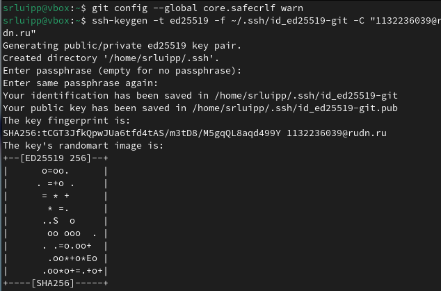

Рисунок 1: git

(рис. 2)

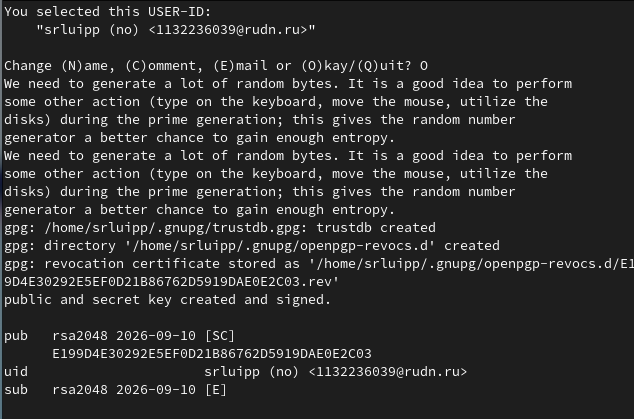

(рис. 3)

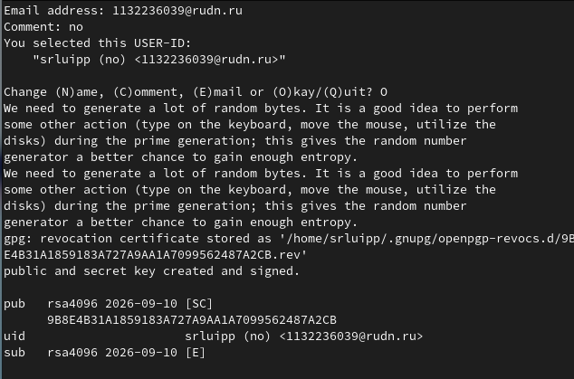

(рис. 4)

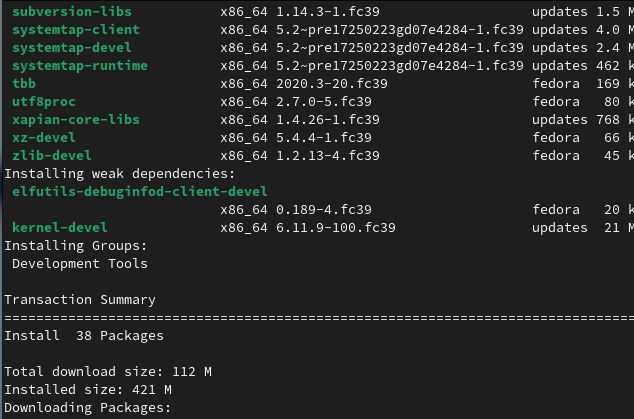

## libxcrypt-compact

Устанавливаю библиотеку libxcrypt-compact(рис. 5).

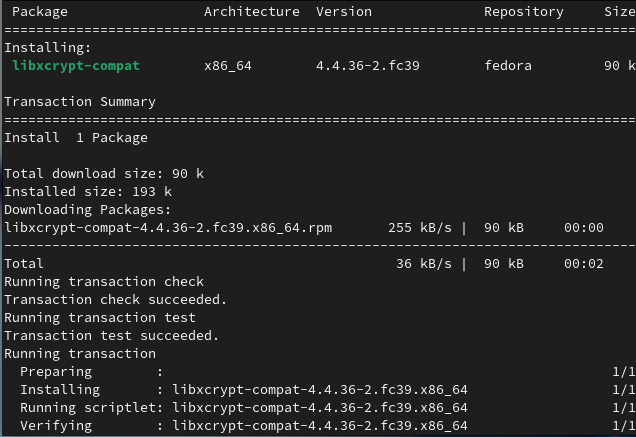

Рисунок 5: libxcrypt-compact

## quarto

Устанавливаю quarto (рис. 6)

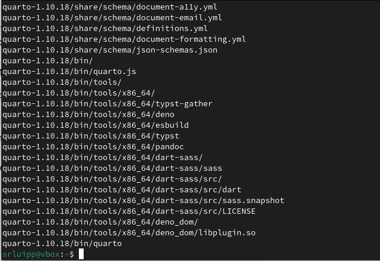

Рисунок 6: quarto

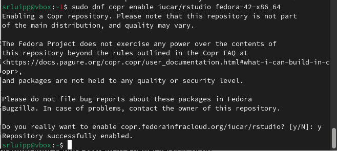

Устанавливаю node.js (рис. 8).

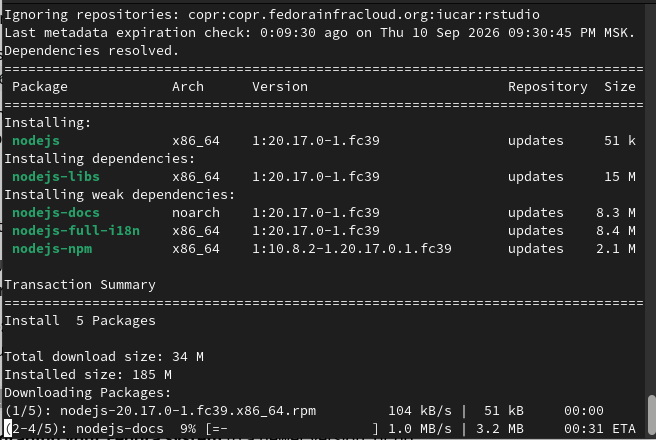

Рисунок 8: nodejs

Устанавливаю pnpm(рис. 9).

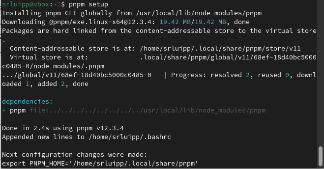

Рисунок 9: pnpm

Устанавливаю pnpm commitzens (рис. 10)

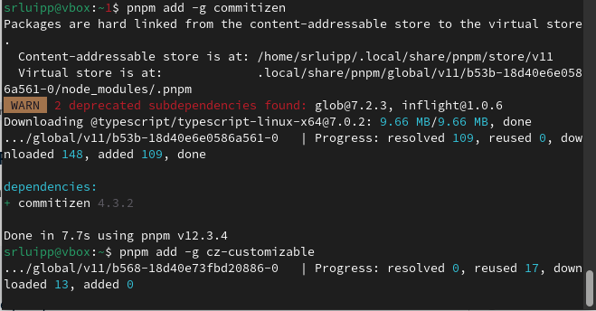

Рисунок 10: pnpm

(рис. 11)

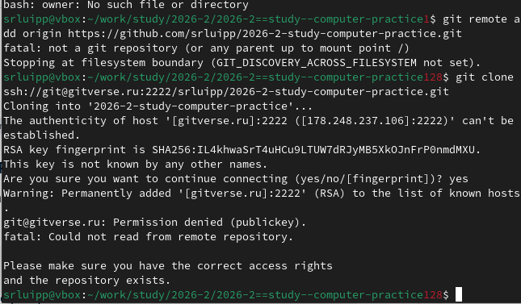

Клонирую репозиторий в GitVerse(рис. 12)

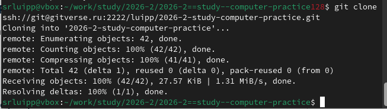

Рисунок 12: git clone

(рис. 13)

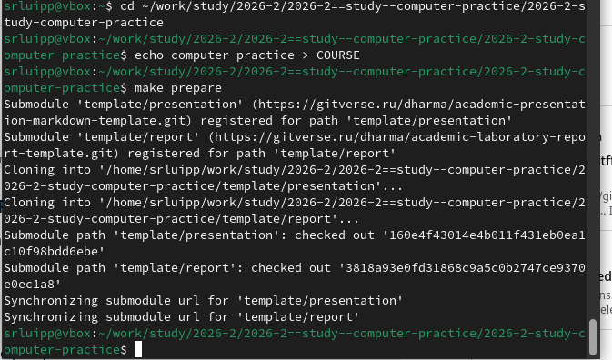

Произвожу команды make и пушу на гит(рис. 14)

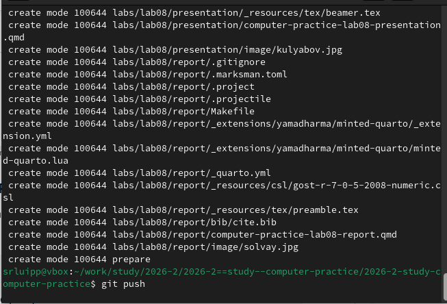

Рисунок 14: make

(рис. 15)

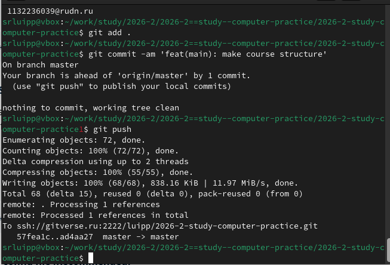

Рисунок 15: make and push

Теперь необходимо установить и распаковать gitflow (рис. 16)

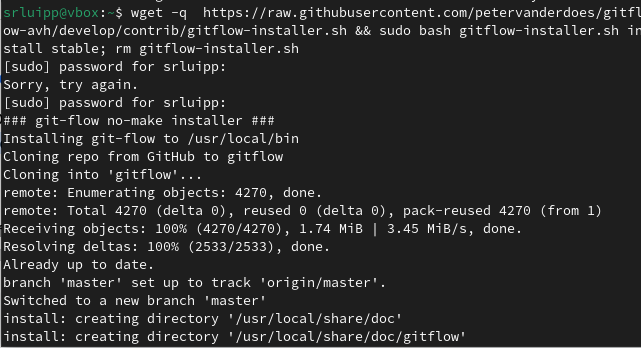

Рисунок 16: gitflow

(рис. 17)

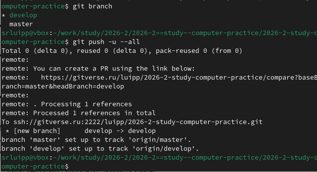

Рисунок 17: gitflow

Настройка branches (рис. 18).

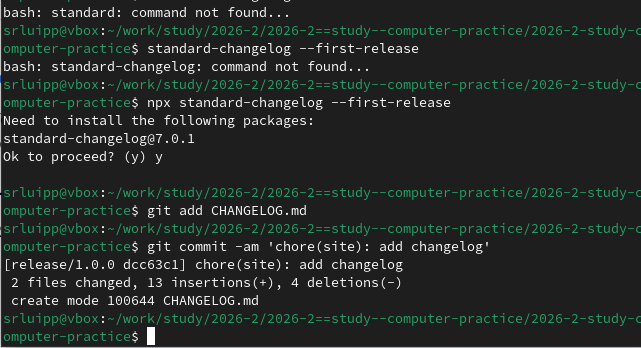

Рисунок 18: branches

Checking the branches (рис. 19)

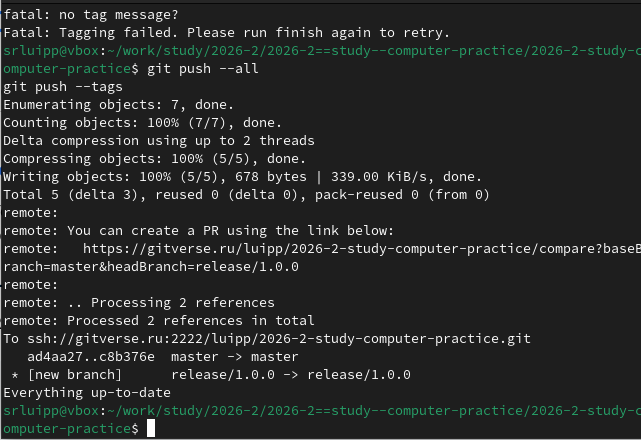

Рисунок 19: branches2

(рис. 20)

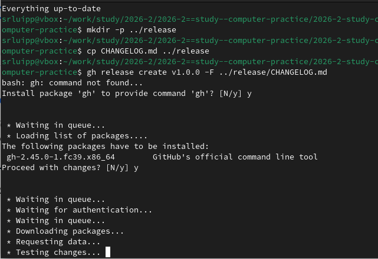

Рисунок 20: branches3

Устанавливаю пакет julia (рис. 21).

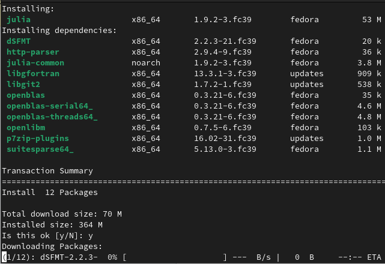

Рисунок 21: julia

Устанавливаю необходимые дополнения для julia (рис. 22)

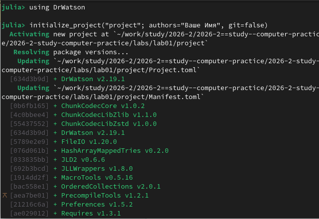

Рисунок 22: julia

(рис. 23)

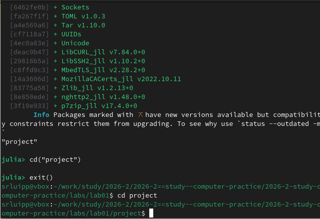

Рисунок 23: julia

(рис. 24)

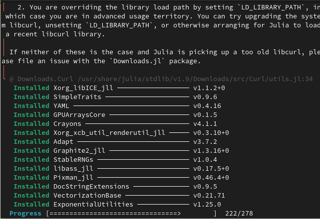

Рисунок 24: julia

# Выводы

В ходе лабораторной работы я приобрела практические навыки работы с системой управления версиями Git, языком программирования Julia.